# Reproducible Research: Peer Assessment 1

## Loading and preprocessing the data

First, we read the date.

```r
act <- read.csv("data/reproducible_research/activity.csv", header = T)
```

Then, let’s see the structure of our dataset.

```r
str(act)
```

```
## 'data.frame':    17568 obs. of  3 variables:
##  $ steps   : int  NA NA NA NA NA NA NA NA NA NA ...
##  $ date    : Factor w/ 61 levels "2012-10-01","2012-10-02",..: 1 1 1 1 1 1 1 1 1 1 ...
##  $ interval: int  0 5 10 15 20 25 30 35 40 45 ...
```

Let’s check the dimensions and a few rows.

```r
dim(act)
```

```
## [1] 17568     3
```

```r
head(act)
```

```
##   steps       date interval
## 1    NA 2012-10-01        0
## 2    NA 2012-10-01        5
## 3    NA 2012-10-01       10
## 4    NA 2012-10-01       15
## 5    NA 2012-10-01       20
## 6    NA 2012-10-01       25
```

The previous output shows we have indeed the number of observations and variables mentioned in the assignment description, and we can see that during the first day of data collection we have several intervals with missing values that we will need to deal later with.

## What is mean total number of steps taken per day?

We use dplyr package to group and summarize the data.

```r
library(dplyr)
act1 <- group_by(act,date)
ave_per_day <- summarize(act1, total=sum(steps, na.rm=T), mean = mean(steps, na.rm = T),
                         median = median(steps, na.rm = T))
```

Once the summaries are calculated, we construct the histogram of the total steps:

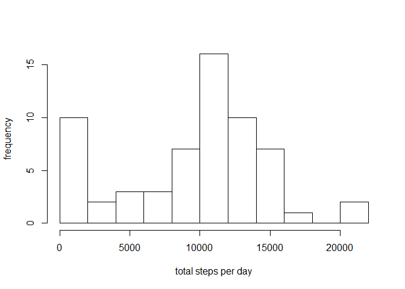

```r
hist(ave_per_day$total, breaks = 15, ylab = "frequency", xlab="total steps per day", main="")
```

```r
summary(ave_per_day$total)
```

```
##    Min. 1st Qu.  Median    Mean 3rd Qu.    Max.
##       0    6778   10400    9354   12810   21190
```

Let’s get a summary of the data, which will include the mean and the median, to get a more quantitative insight of the data:

```r
summary(ave_per_day$total)
```

```
##    Min. 1st Qu.  Median    Mean 3rd Qu.    Max.
##       0    6778   10400    9354   12810   21190
```

```r
summary(ave_per_day$mean)
```

```
##    Min. 1st Qu.  Median    Mean 3rd Qu.    Max.    NA's
##  0.1424 30.7000 37.3800 37.3800 46.1600 73.5900       8
```

Observe that the mean and the median of the total steps are close in value, but also that there are 8 missing values.

## What is the average daily activity pattern?

In this section we will average the number of steps across each 5 min interval, this will give us an idea of the periods where the person might be the most and the least active.

We group the data by interval this time and then calculate the mean of each interval goup:

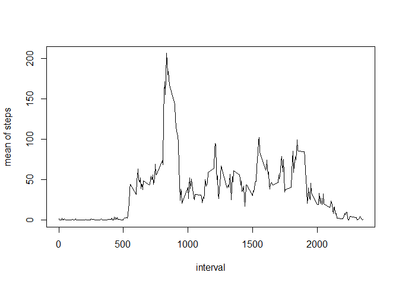

```r
act2 <- group_by(act, interval)
ave_interval <- summarize(act2, mean = mean(steps, na.rm = T))
plot(ave_interval$interval, ave_interval$mean, type = "l", xlab = "interval", ylab = "mean of steps")
max_point <- ave_interval[ave_interval$mean== max(ave_interval$mean),]
points(max_point$interval, max_point$interval, col="red",pch=11)
```

We can observe the largest amount of steps occurs between time intervals 500 and 1000. The maximum average number of steps is: 206 and occurs in time interval #835